# Estatística descritiva com aplicação em Saúde usando R

Parte 2

## Conceitos básicos

Começamos com alguns conceitos básicos, que usaremos durante todo esse curso.

- **População**: Todos os elementos ou indivíduos alvo do estudo;
- **Amostra**: Parte da população;
- **Parâmetro:** característica da população (grandeza);
- **Estimativa:** característica da amostra. Usamos a estimativa para aproximar o parâmetro;
- **Variável:** *característica de um elemento da população (idade ou peso).* Geralmente usamos uma letra maiúscula do alfabeto latino para representar uma variável (idade ou peso), e uma letra minúscula do alfabeto latino para representar o valor de uma variável para um elemento da população. Por exemplo, podemos representar *a variável “idade” por \(X\)* e um *x=30 é idade de um elemento da amostra*.

## Classificação de variáveis

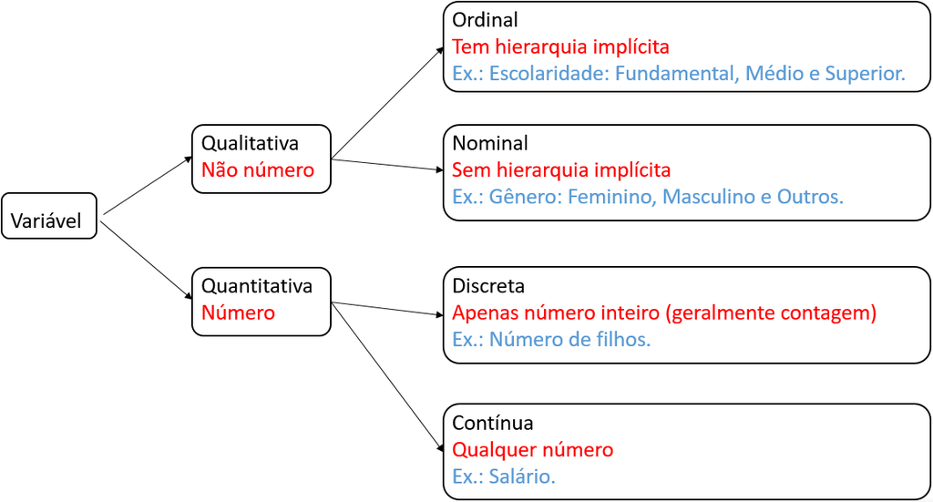

Classificação de variáveis.

## Tabela de distribuição de frequência variável qualitativa

A primeira coisa que fazemos é contar!

| \(X\) | frequência | frequência relativa | porcentagem |
| --- | --- | --- | --- |
| \(B_1\) | \(n_1\) | \(f_1\) | \(100 \cdot f_1\%\) |
| \(B_2\) | \(n_2\) | \(f_2\) | \(100 \cdot f_2\%\) |
| \(\vdots\) | \(\vdots\) | \(\vdots\) | \(\vdots\) |
| \(B_k\) | \(n_k\) | \(f_k\) | \(100 \cdot f_k\%\) |
| Total | \(n\) | \(1\) | \(100\%\) |

Em que \(n\) é o tamanho da amostra.

Geralmente não incluímos a coluna de *frequência relativa*.

## (Re)codificação de variáveis

Precisamos usar o dicionário de variáveis para (re)codificar as variáveis.

```r
df_base_raw <- read_xlsx("data/raw/base_has.xlsx", na = "NA")
df_base_processed <- df_base_raw |>
  mutate(sex = recode(sex, `1` = "M", `2` = "F"),
      racacor = recode(racacor, `1` = "Branca", `2` = "Preta",
                      `3` = "Indígena", `4` = "Parda"),
      esc = recode(esc, `1` = "Fundamental incompleto", `2` = "Médio completo",
                  `3` = "Superior incompleto", `4` = "Superior completo"))
write_xlsx(df_base_processed, "data/processed/base_has_processed.xlsx")
df_base_processed |> select(racacor, sex, esc) |> head(n = 4)
```

```
## # A tibble: 4 × 3
##   racacor sex   esc
##   <chr>   <chr> <chr>
## 1 Parda   M     Superior completo
## 2 Preta   M     Superior completo
## 3 Branca  M     Superior incompleto
## 4 Branca  F     <NA>
```

## Tabela de distribuição de frequência variável qualitativa

**Pacotes:** `janitor`

```r
library(janitor)
df_base_processed |>
    tabyl(sex) |>
    arrange(desc(n)) |>
    adorn_totals() |>
    adorn_pct_formatting(digits = 2) |>
    rename(
        "Gênero" = sex,
        "Frequência" = n,
        "Porcentagem" = percent,
        "Porcentagem sem missing" = valid_percent
    )
```

```
##  Gênero Frequência Porcentagem Porcentagem sem missing
##       M        144      64.00%                  67.29%
##       F         70      31.11%                  32.71%
##    <NA>         11       4.89%                       -
##   Total        225     100.00%                 100.00%
```

## Tabela de distribuição de frequência variável quantitativa discreta

**Pacotes:** `janitor`

```r
library(janitor)
df_mtcarros <- read_csv2("data/raw/mtcarros.csv")
df_mtcarros |>
    tabyl(marchas) |>
    arrange(desc(n)) |>
    adorn_totals() |>
    adorn_pct_formatting(digits = 2) |>
    rename(
        "Marchas" = marchas,
        "Frequência" = n,
        "Porcentagem" = percent
    )
```

```
##  Marchas Frequência Porcentagem
##        3         15      46.88%
##        4         12      37.50%
##        5          5      15.62%
##    Total         32     100.00%
```

## Tabela de distribuição de frequência variável quantitativa contínua

**Primeiro agregamos os valores em intervalos.**

1. Usamos intervalos usados na área de saúde (outro artigo, por exemplo)
2. Regra de Sturge: \(\lceil 1 + \log_2(n) \rceil\) (\(n\) é o tamanho da amostra)

```r
k <- round(1 + log2(nrow(df_base_processed)))
faixas <- seq(
    from = min(df_base_processed$ida, na.rm = TRUE),
    to = max(df_base_processed$ida, na.rm = TRUE),
    length.out = k
)
df_base_processed <- df_base_processed |>
    mutate(faixa_idade = cut(
        ida,
        breaks = faixas,
        include.lowest = T,
        right = F
    ))
```

## Tabela de distribuição de frequência variável quantitativa contínua

```r
df_base_processed |>
    tabyl(faixa_idade) |>
    adorn_totals() |>
    adorn_pct_formatting(digits = 2) |>
    rename(
        "Idade por intervalos" = faixa_idade,
        "Frequência Absoluta" = n,
        "Porcentagem" = percent,
        "Porcentagem sem missing" = valid_percent
    )
```

```
##  Idade por intervalos Frequência Absoluta Porcentagem Porcentagem sem missing
##             [18,25.4)                  43      19.11%                  19.72%
##           [25.4,32.8)                  56      24.89%                  25.69%
##           [32.8,40.1)                  51      22.67%                  23.39%
##           [40.1,47.5)                  33      14.67%                  15.14%
##           [47.5,54.9)                  15       6.67%                   6.88%
##           [54.9,62.2)                  15       6.67%                   6.88%
##           [62.2,69.6)                   2       0.89%                   0.92%
##             [69.6,77]                   3       1.33%                   1.38%
##                  <NA>                   7       3.11%                       -
##                 Total                 225     100.00%                 100.00%
```

## Medidas de Resumo Medidas de posição e dispersão

A ideia é encontrar um ou alguns valores que sintetizem todos os valores.

**Medidas de posição (tendência central)**

A ideia é encontrar um valor que representa *bem* todos os valores.

- **Média:** \(\overline{x} = \dfrac{x_1+\cdots+x_n}{n}\)
- **Mediana:** valor que divide a sequência ordenada de valores em duas partes iguais.

**Medidas de dispersão**

A ideia é medir a homogeneidade dos valores.

- **Variância:** \(s^2 = \dfrac{(x_1 - \overline{X})^2 + \cdots + (x_n - \overline{X})^2}{n-1}\);
- **Desvio padrão:** \(s = \sqrt{s^2}\) (mesma unidade dos dados);
- **coeficiente de variação** \(cv= \dfrac{s}{\overline{x}} \cdot 100\%\) (adimensional, ou seja, “sem unidade”)

## Medidas de resumo

**Pacote:** `dplyr`

```r
df_base_processed |>
    group_by(racacor) |>
    summarise(
        media = mean(imc),
        mediana = median(imc),
        variancia = var(imc),
        dp = sd(imc),
        cv = dp / media,
        frequencia = n()
    )
```

```
## # A tibble: 5 × 7
##   racacor  media mediana variancia    dp     cv frequencia
##   <chr>    <dbl>   <dbl>     <dbl> <dbl>  <dbl>      <int>
## 1 Branca    27.1    27.1      30.4  5.51  0.204        109
## 2 Indígena  24.2    24.2      NA   NA    NA              1
## 3 Parda     27.4    28.8      21.8  4.67  0.171         60
## 4 Preta     27.4    28.5      25.5  5.05  0.184         52
## 5 <NA>      25.4    24.8      19.4  4.40  0.173          3
```

## Quantis

### Ideia

\(q(p)\) é um valor que satisfaz:

- \(100\cdot p\%\) das observações é no máximo \(q(p)\)
- \(100\cdot (1-p)\%\) das observações é no mínimo \(q(p)\)

### Alguns quantis especiais

- **Primeiro quartil:** \(q_1 = q\left(\frac{1}{4}\right)\)
- **Segundo quartil:** \(q_2 = q\left(\frac{2}{4}\right)\)
- **Terceiro quartil:** \(q_3 = q\left(\frac{3}{4}\right)\)

## Quantis

```r
df_base_processed |>
    group_by(sex) |>
    summarise(
        q1 = quantile(imc, 0.25),
        q2 = quantile(imc, 0.5),
        q3 = quantile(imc, 0.75),
        frequencia = n()
    )
```

```
## # A tibble: 3 × 5
##   sex      q1    q2    q3 frequencia
##   <chr> <dbl> <dbl> <dbl>      <int>
## 1 F      21.9  29.1  31.1         70
## 2 M      21.6  27.2  31.1        144
## 3 <NA>   24.8  29.1  31.5         11
```

## Exportando tabelas pacote `gt`

## Pacote `gt`

Vamos usar o pacote `gt` para customizar a apresentação de uma tabela.

A ideia do pacote `gt` é melhorar apresentação por camadas.

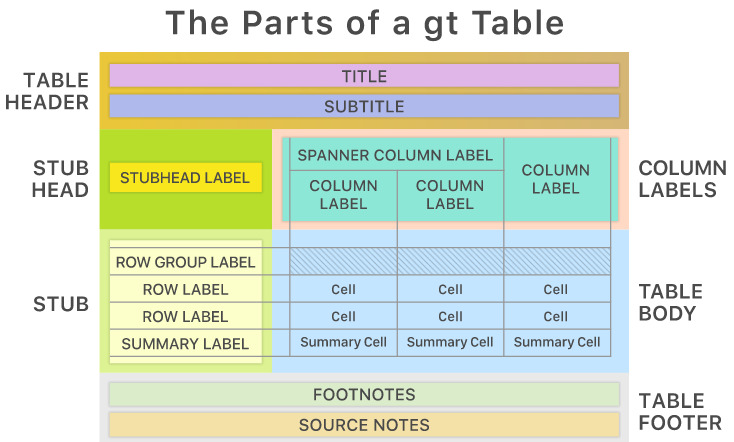

Para mais detalhes, visite [`pacote gt`](https://gt.rstudio.com).

## Exemplo

Vamos customizar e salvar a tabela com as medidas de resumo para a variável `imc` do conjunto de dados *base_.xlsx*.

```r
tab <- df_base_processed |>
    filter(!is.na(racacor) & !is.na(imc) & racacor != "Indígena") |>
    group_by(racacor) |>
    summarise(
        media = mean(imc),
        mediana = median(imc),
        dp = sd(imc),
        cv = dp * 100 / media,
        q1 = quantile(imc, 1 / 4),
        q3 = quantile(imc, 3 / 4)
    )
```

## Cabeçalho e subcabeçalho

- `tab_header`: permite incluir cabeçalho (`title`) e subcabeçalho (`subtitle`)
- `gtsave`: permite salvar tabela em formato `html` (página web), `tex` (\(\LaTeX\)) e `rtf` (word)

```r
library(gt)
gt_tab <- gt(tab) |>
  tab_header(
    title = md("**IMC**"),
    subtitle = md("**por raça autodeclarada**")
  )
gtsave(gt_tab, filename = "output/gt_tab.html")
gtsave(gt_tab, filename = "output/gt_tab.tex")
gtsave(gt_tab, filename = "output/gt_tab.rtf")
```

## Incluindo fonte dos dados

- `tab_source_note`: inclusão de *fonte de dados*
- `md`: formatação de texto usando a sintaxe [`markdown`](https://www.markdownguide.org/cheat-sheet)
- `html`: formatação de texto usando sintaxe [`html`](https://www.w3schools.com/html/html_formatting.asp)

```r
gt_tab <- gt_tab |>
  tab_source_note(
    source_note = md("**Fonte:** Elaboração própria.")
  )
gt_tab
```

**IMC**

**por raça autodeclarada**

| racacor | media | mediana | dp | cv | q1 | q3 |
| --- | --- | --- | --- | --- | --- | --- |
| Branca | 27.05990 | 27.14681 | 5.509258 | 20.35949 | 21.38976 | 31.02041 |
| Parda | 27.36131 | 28.76630 | 4.669262 | 17.06520 | 22.01759 | 31.27128 |
| Preta | 27.43333 | 28.49819 | 5.051074 | 18.41218 | 23.40553 | 31.39357 |

**Fonte:** Elaboração própria.

## Rótulo para grupo de linhas

`tab_row_group`: permite colocar *rótulo* para um grupo de linhas

```r
gt_tab <- gt_tab |>
  tab_row_group(
    label = md("**Pessoas negras**"),
    rows = c(2, 3)
  )
gt_tab
```

**IMC**

**por raça autodeclarada**

| racacor | media | mediana | dp | cv | q1 | q3 |
| --- | --- | --- | --- | --- | --- | --- |
| **Pessoas negras** |  |  |  |  |  |  |
| Parda | 27.36131 | 28.76630 | 4.669262 | 17.06520 | 22.01759 | 31.27128 |
| Preta | 27.43333 | 28.49819 | 5.051074 | 18.41218 | 23.40553 | 31.39357 |
| Branca | 27.05990 | 27.14681 | 5.509258 | 20.35949 | 21.38976 | 31.02041 |

**Fonte:** Elaboração própria.

## Rótulo para grupo de colunas

`tab_spanner`: permite colocar *rótulo* para grupo de colunas

```r
gt_tab <- gt_tab |>
  tab_spanner(
    label = html("<strong>Quantis</strong>"),
    columns = c(q1, mediana, q3)
  )
gt_tab
```

**IMC**

**por raça autodeclarada**

| racacor | media | dp | cv | **Quantis** q1 | **Quantis** mediana | **Quantis** q3 |
| --- | --- | --- | --- | --- | --- | --- |
| **Pessoas negras** |  |  |  |  |  |  |
| Parda | 27.36131 | 4.669262 | 17.06520 | 22.01759 | 28.76630 | 31.27128 |
| Preta | 27.43333 | 5.051074 | 18.41218 | 23.40553 | 28.49819 | 31.39357 |
| Branca | 27.05990 | 5.509258 | 20.35949 | 21.38976 | 27.14681 | 31.02041 |

**Fonte:** Elaboração própria.

## Movendo colunas

- `col_move_to_start`: move uma ou mais colunas para o início da tabela
- `col_move_to_end`: move uma ou mais colunas para o fim da tabela
- `col_move`: move uma coluna ou mais colunas depois uma determinada coluna

```r
gt_tab <- gt_tab |>
    cols_move_to_start(
        columns = racacor
    ) |>
    cols_move_to_end(
        columns = c(q1, mediana, q3)
    ) |>
    cols_move(
        columns = cv,
        after = media
    )
gt_tab
```

**IMC**

**por raça autodeclarada**

| racacor | media | cv | dp | **Quantis** q1 | **Quantis** mediana | **Quantis** q3 |
| --- | --- | --- | --- | --- | --- | --- |
| **Pessoas negras** |  |  |  |  |  |  |
| Parda | 27.36131 | 17.06520 | 4.669262 | 22.01759 | 28.76630 | 31.27128 |
| Preta | 27.43333 | 18.41218 | 5.051074 | 23.40553 | 28.49819 | 31.39357 |
| Branca | 27.05990 | 20.35949 | 5.509258 | 21.38976 | 27.14681 | 31.02041 |

**Fonte:** Elaboração própria.

## Atualização dos rótulos das colunas

`cols_label`: permite atualizar os *rótulos* de colunas

```r
gt_tab <- gt_tab |>
    cols_label(
        racacor = md("_Raça_"),
        media = html("<em>Média</em>"),
        cv = md("_Coeficiente de variação_"),
        dp = html("<em>Desvio padrão</em>"),
        q1 = md("_Primeiro quartil_"),
        mediana = html("<em>Segundo quartil</em>"),
        q3 = md("_Terceiro quartil_")
    )
gt_tab
```

**IMC**

**por raça autodeclarada**

| *Raça* | *Média* | *Coeficiente de variação* | *Desvio padrão* | **Quantis** *Primeiro quartil* | **Quantis** *Segundo quartil* | **Quantis** *Terceiro quartil* |
| --- | --- | --- | --- | --- | --- | --- |
| **Pessoas negras** |  |  |  |  |  |  |
| Parda | 27.36131 | 17.06520 | 4.669262 | 22.01759 | 28.76630 | 31.27128 |
| Preta | 27.43333 | 18.41218 | 5.051074 | 23.40553 | 28.49819 | 31.39357 |
| Branca | 27.05990 | 20.35949 | 5.509258 | 21.38976 | 27.14681 | 31.02041 |

**Fonte:** Elaboração própria.

## Formatação de valores nas colunas

`fmt_number:` formatação de valores numéricos em uma tabela

```r
gt_tab <- gt_tab |>
    fmt_number(
        columns = c(media, mediana, dp, q1, q3),
        decimals = 2,
        dec_mark = ",",
        sep_mark = "."
    ) |>
    fmt_number(
        columns = cv,
        decimals = 2,
        dec_mark = ",",
        sep_mark = ".",
        pattern = "{x}%"
    )
gt_tab
```

**IMC**

**por raça autodeclarada**

| *Raça* | *Média* | *Coeficiente de variação* | *Desvio padrão* | **Quantis** *Primeiro quartil* | **Quantis** *Segundo quartil* | **Quantis** *Terceiro quartil* |
| --- | --- | --- | --- | --- | --- | --- |
| **Pessoas negras** |  |  |  |  |  |  |
| Parda | 27,36 | 17,07% | 4,67 | 22,02 | 28,77 | 31,27 |
| Preta | 27,43 | 18,41% | 5,05 | 23,41 | 28,50 | 31,39 |
| Branca | 27,06 | 20,36% | 5,51 | 21,39 | 27,15 | 31,02 |

**Fonte:** Elaboração própria.

## Gráficos `ggplot2`

## Gráficos no `R`

- **Pacote:** `ggplot2`
- Permite gráficos personalizados com uma sintaxe simples e rápida, e iterativa *por camadas*
- Começamos com um camada com os dados `ggplot(dados)`, e vamos adicionando as camadas de anotações, e sumários estatísticos
- Usa a *gramática de gráficos* proposta por Leland Wilkinson: [Grammar of Graphics](https://www.springer.com/gp/book/9780387245447)
- Ideia desta gramática: delinear os atributos estéticos das figuras geométricas (incluindo transformações nos dados e mudança no sistema de coordenadas)
- Para mais detalhes, você pode consultar [`ggplot2`: elegant graphics for data analysis](https://ggplot2-book.org) e [documentação do `ggplot2`](https://ggplot2.tidyverse.org)

## Estrutura básica `ggplot2`

```r
#| eval: false
ggplot(data = <data possible tibble>) +
  <Geom functions>(mapping = aes(<MAPPINGS>)) +
  <outras camadas>
```

Você pode usar diversos temas e extensões que a comunidade cria e criou para melhorar a aparência e facilitar a construção de `ggplot2`.

- Lista com extensões do `ggplot`: [extensões do `ggplots`](https://exts.ggplot2.tidyverse.org/gallery/)

Indicação de extensões:

- Temas adicionais para o pacote `ggplot2`: [`ggthemes`](https://jrnold.github.io/ggthemes/index.html)
- Gráfico de matriz de correlação: [`ggcorrplot`](https://rpkgs.datanovia.com/ggcorrplot/)
- Gráfico quantil-quantil: [`qqplotr`](https://aloy.github.io/qqplotr/)

## Gráfico de barras

#### Gráfico de Barras no `ggplot2`

- **função:** `geom_bar()`. Para porcentagem: `geom_bar(x = <variável no eixo x>, y = ..prop.. * 100)`.
- Argumentos adicionais:
  - **`fill`**: mudar a cor do preenchimento das figuras geométricas
  - **`color`**: mudar a cor da figura geométrica

#### Rótulos dos eixos

- **Mudar os rótulos:** `labs(x = <rótulo do eixo x>, y = <rótulo do eixo y>, title = <legenda do gráfico>)`
- **Trocar o eixo-x pelo eixo-y:** `coord_flip()`

#### Salvar gráficos

- `ggsave()`: salvar gráficos nos formatos `pdf`, `png` e `jpeg`

## Gráfico de barras

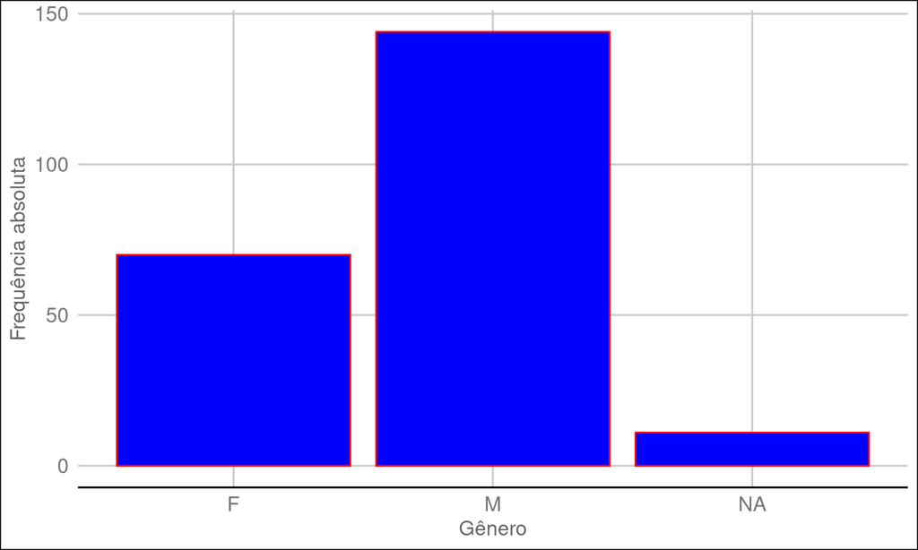

```r
library(ggplot2)
library(ggthemes)
ggplot(df_base_processed) +
    geom_bar(aes(x = sex), fill = "blue", color = "red") +
    labs(x = "Gênero", y = "Frequência absoluta") +
    theme_gdocs()
ggsave("figures/barras.jpeg")
ggsave("figures/barras.png")
ggsave("figures/barras.pdf")
```

## Histograma

Para variávieis quantitativas contínuas usamos *histograma*.

- O histograma é um gráfico de barras contíguas em que a área de cada barra é igual à frequência relativa.
- Cada faixa de valor \([l_{i-1}, l_{i}), i=1, \dots, n,\) será representada por um barra com área \(f_i, i=1, \dots, n\).
- Como cada barra terá área igual a \(f_i\) e base \(\Delta_i = l_i - l_{i-1}\), e a altura de cada barra será \(\frac{f_i}{l_i - l_{i-1}}\).
- \(\frac{f_i}{l_i - l_{i-1}}\) é denominada de densidade de frequência.
- Podemos fornecer:
  - `bins`: número de intervalos
  - `binwidth`: tamanho dos intervalos
  - `breaks`: limites dos intervalos

## Histograma

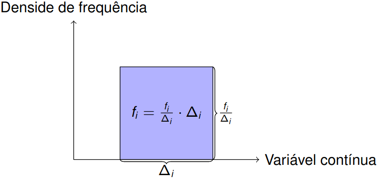

## Histograma

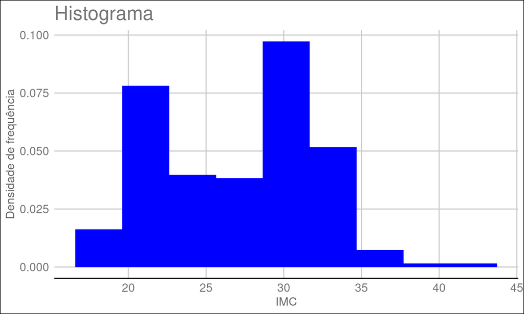

```r
k <- round(1 + log2(nrow(df_base_processed)))

ggplot(df_base_processed) +
  geom_histogram(aes(x = imc, y = ..density..),
                bins = k, fill = "blue", closed = "left") +
  theme_gdocs() +
  labs(
    x = "IMC",
    y = "Densidade de frequência",
    title = "Histograma"
  )
```

## Diagrama de caixa

**medida de dispersão:** distância entre \(q_1\) e \(q_3\) pequena indica homogeneidade

**Diferença de quartis:** \(dq = q_3 - q_1\)

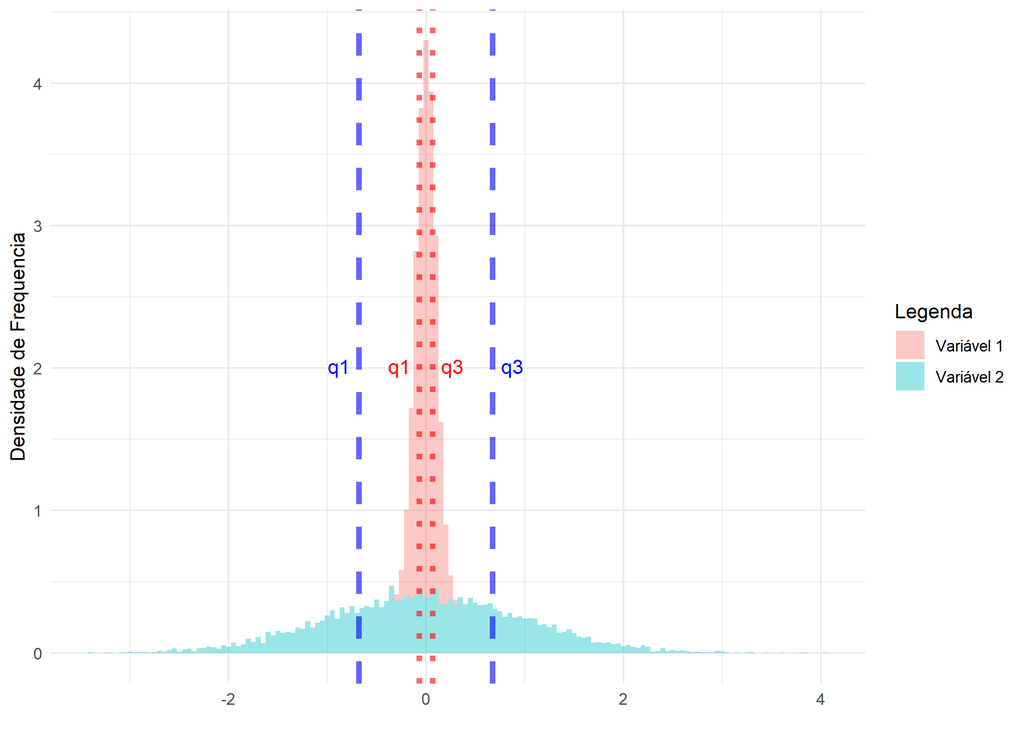

## Diagrama de caixa

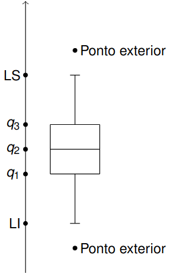

## Diagrama de caixa

**Assimetria**

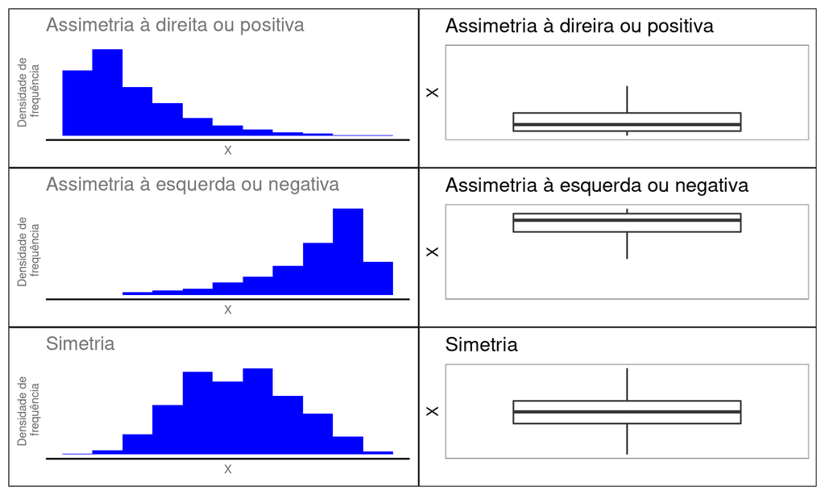

## Diagrama de caixa

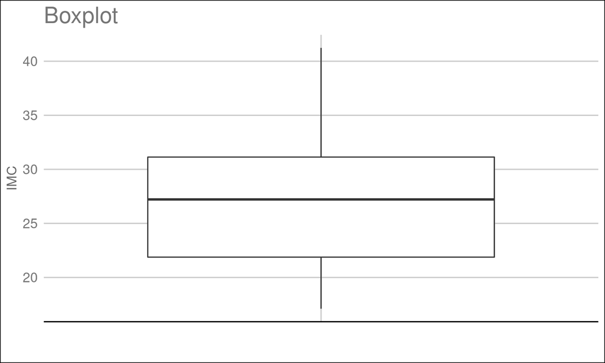

```r
ggplot(df_base_processed) +
  geom_boxplot(aes(x = "", y = imc)) +
  labs(x = "", y = "IMC", title = "Boxplot") +
  theme_gdocs()
```

## Gráficos lado a lado com `patchwork`

- `patchwork` permite colocar gráficos lado a lado com os operadores binários `+` (ao lado) e `\` (embaixo)
- Mais detalhes em [documentação `patchwork`](https://patchwork.data-imaginist.com/articles/patchwork.html)

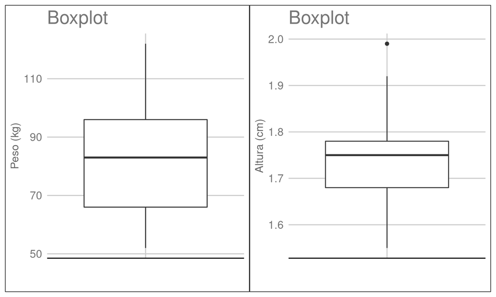

```r
g1 <- ggplot(df_base_processed) +
  geom_boxplot(aes(x = "", y = pes)) +
  labs(x = "", y = "Peso (kg)", title = "Boxplot") +
  theme_gdocs()
g2 <- ggplot(df_base_processed) +
  geom_boxplot(aes(x = "", y = alt)) +
  labs(x = "", y = "Altura (cm)", title = "Boxplot") +
  theme_gdocs()
g1 + g2
```

## Gráficos Duas variáveis

## Gráfico de dispersão

**Ideia:** estudar a associação entre duas variáveis quantitativas

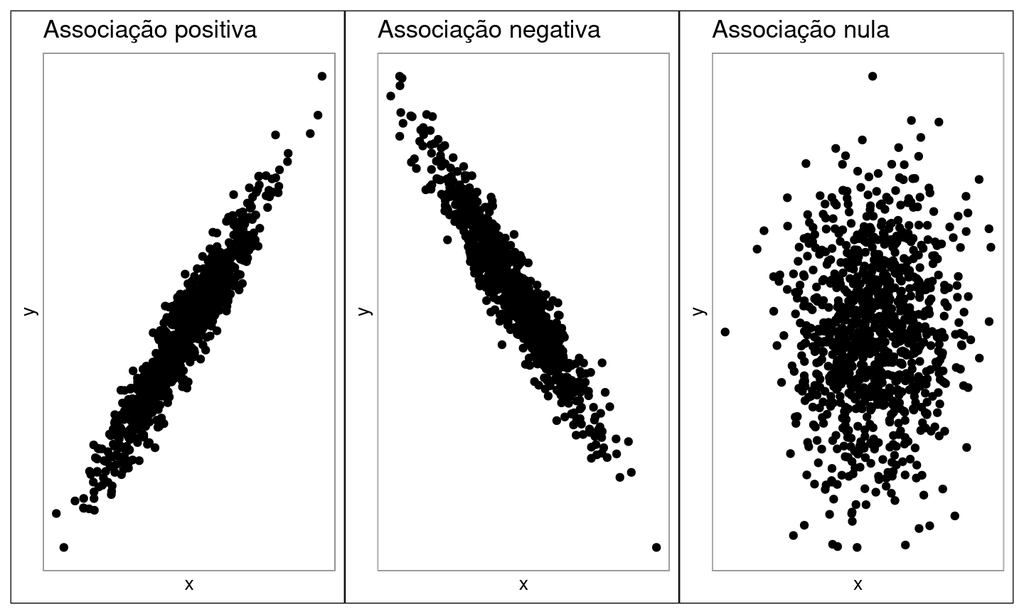

## Gráfico de dispersão

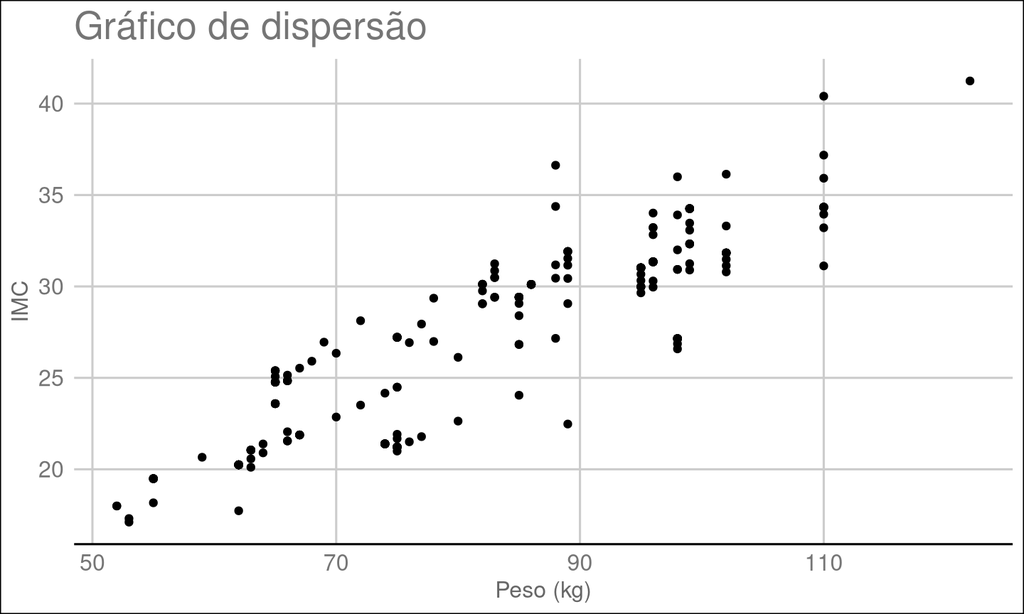

```r
ggplot(df_base_processed) +
  geom_point(aes(pes, imc)) +
  labs(
    x = "Peso (kg)",
    y = "IMC",
    title = "Gráfico de dispersão"
  ) +
  theme_gdocs()
```

## Gráfico de barras

**Ideia**

Sejam \(X\) e \(Y\) duas variáveis qualitativas com seguintes valores possíveis

- \(X\): \(A_1, \dots, A_r\)
- \(Y\). \(B_1, \dots, B_s\)

Desejamos estudar a associação entre \(X\) e \(Y\).

**Associação entre \(X\) e \(Y\)**

Suponha que \(A_i\) tenha porcentagem \(f_i\cdot 100\%\). Então, \(X\) e \(Y\) são:

- **não associados** se ao conhecermos o valor de \(Y\) para um elemento da população, *continuamos* com a porcentagem \(100\cdot f_i \%\) deste elemento ter valor de \(X\) igual a \(A_i\)
- **associados** se ao conhecermos o valor de \(Y\) para um elemento da população, *alteramos* a porcentagem \(100\cdot f_i\%\) deste elemento ter valor de \(X\) igual a \(A_i\)

## Gráfico de barras

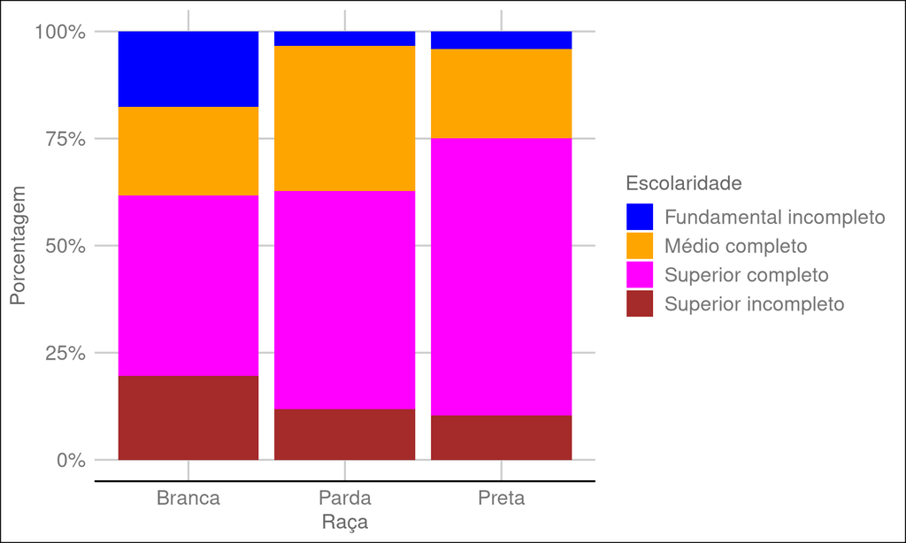

```r
df_filtrada <- df_base_processed |>
  filter(racacor != "Indígena" & !is.na(racacor) & !is.na(esc))
ggplot(df_filtrada) +
  geom_bar(aes(x = racacor, fill = esc), position = "fill") +
  labs(x = "Raça", y = "Porcentagem") +
  scale_y_continuous(labels = scales::percent)+
  scale_fill_manual(name = "Escolaridade", values = c("blue", "orange", "magenta", "brown")) +
  theme_gdocs()
```

## Gráfico de barras

Podemos agrupar as barras por grupos para analisar a associação entre duas variáveis qualitativas.

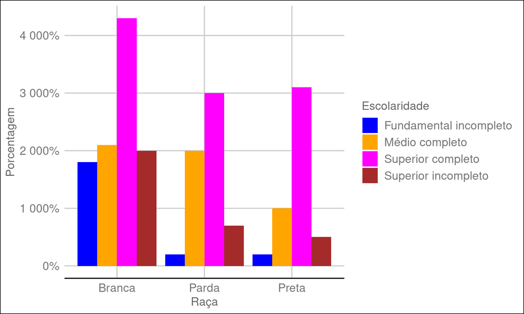

```r
df_filtrada <- df_base_processed |>
  filter(racacor != "Indígena" & !is.na(racacor) & !is.na(esc))
ggplot(df_filtrada) +
  geom_bar(aes(x = racacor, fill = esc), position = "dodge") +
  labs(x = "Raça", y = "Porcentagem") +
  scale_y_continuous(labels = scales::percent)+
  scale_fill_manual(name = "Escolaridade", values = c("blue", "orange", "magenta", "brown")) +
  theme_gdocs()
```

## Diagrama de caixa

Podemos comparar medianas de diferentes grupos usando o diagrama de caixa.

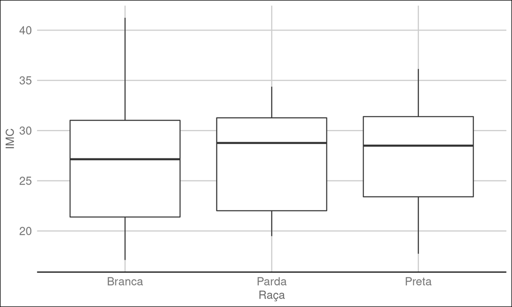

```r
df_filtrada <- df_base_processed |>
  filter(racacor != "Indígena" & !is.na(racacor) & !is.na(imc))
ggplot(df_filtrada) +
  geom_boxplot(aes(x = racacor, y = imc)) +
  labs(x = "Raça", y = "IMC") +
  theme_gdocs()
```